# Project _ CreditCard Users Churn Prediction (DA)

### Project:

https://olympus.greatlearning.in/courses/37429/assignments/138792

Customers’ leaving credit cards services would lead bank to loss, so the bank wants to analyze the data of customers’ and identify the customers who will leave their credit card services and reason for same – so that bank could improve upon those areas

You as a Data scientist at Thera bank need to come up with a classification model that will help bank improve their services so that customers do not renounce their credit cards

### Objective

Explore and visualize the dataset. Build a classification model to predict if the customer is going to churn or not Optimize the model using appropriate techniques Generate a set of insights and recommendations that will help the bank

### Sections

EDA w\ Insights

- Univariate analysis & Bivariate analysis

Final EDA Insight: Key meaningful observations on the relationship between variables

Data Pre-processing

- Prepare the data for analysis
  - Missing value Treatment, Outlier Detection(treat, if needed. why or why not ), Feature Engineering, Prepare data for modeling

Model building-Logistic Regression

- Make a logistic regression model
- Improve model performance (up/downsampling)
- Regularize above models, if required

Model building-Bagging and Boosting

- Build Decision tree, random forest, bagging classifier models
- Build Xgboost, AdaBoost, and gradient boosting models

Hyperparameter tuning using grid search: **GridSearchCV()**

- Tune the best 3 models using grid search and provide the reason behind choosing those models
- Use pipelines in hyperparameter tuning

Hyperparameter tuning using random searchL: **RandomizedSearchCV()**

- Tune the best 3 models using random search and provide the reason behind choosing those models
- Use pipelines in hyperparameter tuning

Model Performances

- Compare the model performance of all the models
- Comment on the time taken by the grid and randomized search in optimization

Business recommendations and insights

### Library Imports

```python
# Library to suppress warnings or deprecation notes
import warnings
warnings.filterwarnings('ignore')

######[Perform an Exploratory Data Analysis] ###############################
###   - Univariate analysis
###   - Bivariate analysis
###   - Use appropriate visualizations to identify the patterns and insights
###   - Any other exploratory deep dive
###  Illustrate the insights based on EDA
###   - Key meaningful observations on the relationship between variables
import numpy as np
import pandas as pd
import seaborn as sns
import matplotlib.pyplot as plt
from time import time
%matplotlib inline


#####[Data Pre-processing] ################################################
##  - Prepare the data for analysis
##  - Missing value Treatment, Outlier Detection
##   , Feature Engineering, Prepare data for modeling
from sklearn.impute import SimpleImputer
from sklearn.model_selection import train_test_split  #Train,Validation,Test


######[Model building - LOGISTIC REGRESSION]###############################
###  - Make a logistic regression model
###  - Improve model performance by UP/DOWN -sampling
###  - REGULARIZE above models, if required
###
from sklearn.linear_model import LogisticRegression


######[Model building - Bagging and Boosting] #############################
### - Build Decision Tree, Random Forest, Bagging Classifier
### - Build Xgboost, AdaBoost, Gradient Boosting models
from sklearn.tree import DecisionTreeClassifier
from sklearn.ensemble import RandomForestClassifier
from sklearn.ensemble import BaggingClassifier

from xgboost import XGBClassifier
from sklearn.ensemble import AdaBoostClassifier
from sklearn.ensemble import GradientBoostingClassifier
# from sklearn.ensemble import StackingClassifier


#####[Hyperparameter tuning using GRID SEARCH & RANDOM SEARCH]############
### - Tune the best 3 models using GRID SEARCH & RANDOM SEARCH and provide the reason behind choosing those models
### - Use pipelines in hyperparameter tuning
from sklearn.pipeline import make_pipeline
from sklearn.pipeline import Pipeline


#####[Model Performances]############
### - Compare the model performance of all the models
### - Comment on the time taken by the GRID and RANDOMIZED SEARCH in optimization
from sklearn import metrics
from sklearn.metrics import confusion_matrix, classification_report
from sklearn.metrics import accuracy_score, precision_score, recall_score

#!!!!!!!!!!!!!!!!!!!!!!!!!!!!!!!!!!!!!!!!!!!!!!!!!!!!!!!!!!!!!!!!!!!!!!!!!!!!!!
# Actionable Insights & Recommendations- Business recommendations and insights
# Notebook - Overall quality- Structure and flow - Well commented code
#!!!!!!!!!!!!!!!!!!!!!!!!!!!!!!!!!!!!!!!!!!!!!!!!!!!!!!!!!!!!!!!!!!!!!!!!!!!!!!

from sklearn.model_selection import cross_val_score
from sklearn.svm import SVC
from sklearn.decomposition import PCA
from sklearn.impute import KNNImputer
from sklearn.model_selection import StratifiedKFold
from sklearn.model_selection import GridSearchCV
from sklearn.model_selection import RandomizedSearchCV



# from sklearn.preprocessing import MinMaxScaler
from sklearn.preprocessing import StandardScaler
# from sklearn.preprocessing import LabelEncoder
# from sklearn.preprocessing import RandomForestClassifier


# ~~~~~~~~~~~~~~~~~~~~~~~~~~~~~~~~~~~~~~~~~~~~~~~~~~~~~~~~~~~~~~~~~~~~~~~~~~~~~~~~~~~~~~~~~~~~~~~~~~~~~~~~~~~~

warnings.filterwarnings("ignore")
# Libraries to help with reading and manipulating data
import pandas as pd
import numpy as np

# libaries to help with data visualization
%matplotlib inline
import matplotlib.pyplot as plt
import seaborn as sns

# Libraries to tune model, get different metric scores, and split data
from sklearn import metrics
from sklearn.model_selection import train_test_split, StratifiedKFold, cross_val_score
from sklearn.preprocessing import StandardScaler
from sklearn.model_selection import GridSearchCV, RandomizedSearchCV

from sklearn.impute import KNNImputer
from sklearn.pipeline import Pipeline, make_pipeline

#libraries to help with model building
from sklearn.linear_model import LogisticRegression
from sklearn.tree import DecisionTreeClassifier
from sklearn.ensemble import (
    AdaBoostClassifier,
    GradientBoostingClassifier,
    RandomForestClassifier)
from xgboost import XGBClassifier
```

### Load Dataset

```python
mydata=pd.read_csv("BankChurners.csv")
print(20*"*")
print("Null values:", mydata.isnull().values.any())
print(20*"*")
print(mydata.info())
```

```
Null values: False
<class 'pandas.core.frame.DataFrame'>
RangeIndex: 10127 entries, 0 to 10126
Data columns (total 21 columns):
 #   Column                    Non-Null Count  Dtype
---  ------                    --------------  -----
 0   CLIENTNUM                 10127 non-null  int64
 1   Attrition_Flag            10127 non-null  object
 2   Customer_Age              10127 non-null  int64
 3   Gender                    10127 non-null  object
 4   Dependent_count           10127 non-null  int64
 5   Education_Level           10127 non-null  object
 6   Marital_Status            10127 non-null  object
 7   Income_Category           10127 non-null  object
 8   Card_Category             10127 non-null  object
 9   Months_on_book            10127 non-null  int64
 10  Total_Relationship_Count  10127 non-null  int64
 11  Months_Inactive_12_mon    10127 non-null  int64
 12  Contacts_Count_12_mon     10127 non-null  int64
 13  Credit_Limit              10127 non-null  float64
 14  Total_Revolving_Bal       10127 non-null  int64
 15  Avg_Open_To_Buy           10127 non-null  float64
 16  Total_Amt_Chng_Q4_Q1      10127 non-null  float64
 17  Total_Trans_Amt           10127 non-null  int64
 18  Total_Trans_Ct            10127 non-null  int64
 19  Total_Ct_Chng_Q4_Q1       10127 non-null  float64
 20  Avg_Utilization_Ratio     10127 non-null  float64
dtypes: float64(5), int64(10), object(6)
memory usage: 1.6+ MB
None
```

- Data contains no explicit Null Values in 21 columns & 10127 entries
- Most data is in float/in format, only 6 columns are objects
- Ok to drop CLIENTNUM column non-value add since its the same 10127 of records

```python
myTARGET='Attrition_Flag'

#Drop identification
mydata.drop(columns='CLIENTNUM', inplace=True)

#Backup data
mydata_bkup=mydata.copy()

#First View of data
mydata.transpose()
```

|  | 0 | 1 | 2 | 3 | 4 | 5 | 6 | 7 | 8 | 9 | ... | 10117 | 10118 | 10119 | 10120 | 10121 | 10122 | 10123 | 10124 | 10125 | 10126 |
| --- | --- | --- | --- | --- | --- | --- | --- | --- | --- | --- | --- | --- | --- | --- | --- | --- | --- | --- | --- | --- | --- |
| Attrition_Flag | Existing Customer | Existing Customer | Existing Customer | Existing Customer | Existing Customer | Existing Customer | Existing Customer | Existing Customer | Existing Customer | Existing Customer | ... | Existing Customer | Attrited Customer | Attrited Customer | Existing Customer | Existing Customer | Existing Customer | Attrited Customer | Attrited Customer | Attrited Customer | Attrited Customer |
| Customer_Age | 45 | 49 | 51 | 40 | 40 | 44 | 51 | 32 | 37 | 48 | ... | 57 | 50 | 55 | 54 | 56 | 50 | 41 | 44 | 30 | 43 |
| Gender | M | F | M | F | M | M | M | M | M | M | ... | M | M | F | M | F | M | M | F | M | F |
| Dependent_count | 3 | 5 | 3 | 4 | 3 | 2 | 4 | 0 | 3 | 2 | ... | 2 | 1 | 3 | 1 | 1 | 2 | 2 | 1 | 2 | 2 |
| Education_Level | High School | Graduate | Graduate | High School | Uneducated | Graduate | Unknown | High School | Uneducated | Graduate | ... | Graduate | Unknown | Uneducated | High School | Graduate | Graduate | Unknown | High School | Graduate | Graduate |
| Marital_Status | Married | Single | Married | Unknown | Married | Married | Married | Unknown | Single | Single | ... | Married | Unknown | Single | Single | Single | Single | Divorced | Married | Unknown | Married |
| Income_Category | $60K - $80K | Less than $40K | $80K - $120K | Less than $40K | $60K - $80K | $40K - $60K | $120K + | $60K - $80K | $60K - $80K | $80K - $120K | ... | $80K - $120K | $80K - $120K | Unknown | $60K - $80K | Less than $40K | $40K - $60K | $40K - $60K | Less than $40K | $40K - $60K | Less than $40K |
| Card_Category | Blue | Blue | Blue | Blue | Blue | Blue | Gold | Silver | Blue | Blue | ... | Blue | Blue | Blue | Blue | Blue | Blue | Blue | Blue | Blue | Silver |
| Months_on_book | 39 | 44 | 36 | 34 | 21 | 36 | 46 | 27 | 36 | 36 | ... | 40 | 36 | 47 | 34 | 50 | 40 | 25 | 36 | 36 | 25 |
| Total_Relationship_Count | 5 | 6 | 4 | 3 | 5 | 3 | 6 | 2 | 5 | 6 | ... | 6 | 6 | 4 | 5 | 4 | 3 | 4 | 5 | 4 | 6 |
| Months_Inactive_12_mon | 1 | 1 | 1 | 4 | 1 | 1 | 1 | 2 | 2 | 3 | ... | 3 | 3 | 3 | 2 | 1 | 2 | 2 | 3 | 3 | 2 |
| Contacts_Count_12_mon | 3 | 2 | 0 | 1 | 0 | 2 | 3 | 2 | 0 | 3 | ... | 4 | 4 | 3 | 0 | 4 | 3 | 3 | 4 | 3 | 4 |
| Credit_Limit | 12691 | 8256 | 3418 | 3313 | 4716 | 4010 | 34516 | 29081 | 22352 | 11656 | ... | 17925 | 9959 | 14657 | 13940 | 3688 | 4003 | 4277 | 5409 | 5281 | 10388 |
| Total_Revolving_Bal | 777 | 864 | 0 | 2517 | 0 | 1247 | 2264 | 1396 | 2517 | 1677 | ... | 1909 | 952 | 2517 | 2109 | 606 | 1851 | 2186 | 0 | 0 | 1961 |
| Avg_Open_To_Buy | 11914 | 7392 | 3418 | 796 | 4716 | 2763 | 32252 | 27685 | 19835 | 9979 | ... | 16016 | 9007 | 12140 | 11831 | 3082 | 2152 | 2091 | 5409 | 5281 | 8427 |
| Total_Amt_Chng_Q4_Q1 | 1.335 | 1.541 | 2.594 | 1.405 | 2.175 | 1.376 | 1.975 | 2.204 | 3.355 | 1.524 | ... | 0.712 | 0.825 | 0.166 | 0.66 | 0.57 | 0.703 | 0.804 | 0.819 | 0.535 | 0.703 |
| Total_Trans_Amt | 1144 | 1291 | 1887 | 1171 | 816 | 1088 | 1330 | 1538 | 1350 | 1441 | ... | 17498 | 10310 | 6009 | 15577 | 14596 | 15476 | 8764 | 10291 | 8395 | 10294 |
| Total_Trans_Ct | 42 | 33 | 20 | 20 | 28 | 24 | 31 | 36 | 24 | 32 | ... | 111 | 63 | 53 | 114 | 120 | 117 | 69 | 60 | 62 | 61 |
| Total_Ct_Chng_Q4_Q1 | 1.625 | 3.714 | 2.333 | 2.333 | 2.5 | 0.846 | 0.722 | 0.714 | 1.182 | 0.882 | ... | 0.82 | 1.1 | 0.514 | 0.754 | 0.791 | 0.857 | 0.683 | 0.818 | 0.722 | 0.649 |
| Avg_Utilization_Ratio | 0.061 | 0.105 | 0 | 0.76 | 0 | 0.311 | 0.066 | 0.048 | 0.113 | 0.144 | ... | 0.106 | 0.096 | 0.172 | 0.151 | 0.164 | 0.462 | 0.511 | 0 | 0 | 0.189 |

20 rows × 10127 columns

```python
# Creating columns based on what seems to be CATEGORICAL & CONTINUOUS features.
mycontcols=['Avg_Open_To_Buy','Avg_Utilization_Ratio','Contacts_Count_12_mon','Credit_Limit','Customer_Age'
,'Dependent_count','Months_Inactive_12_mon','Months_on_book','Total_Amt_Chng_Q4_Q1','Total_Ct_Chng_Q4_Q1'
,'Total_Relationship_Count','Total_Revolving_Bal','Total_Trans_Amt','Total_Trans_Ct']

mycatcols=['Attrition_Flag' ,'Card_Category' ,'Education_Level' ,'Gender' ,'Income_Category' ,'Marital_Status']
```

```python
mydata.describe().T.sort_values(by='mean')
#mydata.describe().T.sort_values(by='mean').index[:]
```

|  | count | mean | std | min | 25% | 50% | 75% | max |
| --- | --- | --- | --- | --- | --- | --- | --- | --- |
| Avg_Utilization_Ratio | 10127.0 | 0.274894 | 0.275691 | 0.0 | 0.023 | 0.176 | 0.503 | 0.999 |
| Total_Ct_Chng_Q4_Q1 | 10127.0 | 0.712222 | 0.238086 | 0.0 | 0.582 | 0.702 | 0.818 | 3.714 |
| Total_Amt_Chng_Q4_Q1 | 10127.0 | 0.759941 | 0.219207 | 0.0 | 0.631 | 0.736 | 0.859 | 3.397 |
| Months_Inactive_12_mon | 10127.0 | 2.341167 | 1.010622 | 0.0 | 2.000 | 2.000 | 3.000 | 6.000 |
| Dependent_count | 10127.0 | 2.346203 | 1.298908 | 0.0 | 1.000 | 2.000 | 3.000 | 5.000 |
| Contacts_Count_12_mon | 10127.0 | 2.455317 | 1.106225 | 0.0 | 2.000 | 2.000 | 3.000 | 6.000 |
| Total_Relationship_Count | 10127.0 | 3.812580 | 1.554408 | 1.0 | 3.000 | 4.000 | 5.000 | 6.000 |
| Months_on_book | 10127.0 | 35.928409 | 7.986416 | 13.0 | 31.000 | 36.000 | 40.000 | 56.000 |
| Customer_Age | 10127.0 | 46.325960 | 8.016814 | 26.0 | 41.000 | 46.000 | 52.000 | 73.000 |
| Total_Trans_Ct | 10127.0 | 64.858695 | 23.472570 | 10.0 | 45.000 | 67.000 | 81.000 | 139.000 |
| Total_Revolving_Bal | 10127.0 | 1162.814061 | 814.987335 | 0.0 | 359.000 | 1276.000 | 1784.000 | 2517.000 |
| Total_Trans_Amt | 10127.0 | 4404.086304 | 3397.129254 | 510.0 | 2155.500 | 3899.000 | 4741.000 | 18484.000 |
| Avg_Open_To_Buy | 10127.0 | 7469.139637 | 9090.685324 | 3.0 | 1324.500 | 3474.000 | 9859.000 | 34516.000 |
| Credit_Limit | 10127.0 | 8631.953698 | 9088.776650 | 1438.3 | 2555.000 | 4549.000 | 11067.500 | 34516.000 |

**Basic Data Scoping**

  The following continous int64 values are more catigorical than continous.
- Dependent_count
- Total_Relationship_Count
- Contacts_Count_12_mon
- Months_Inactive_12_mon

**Distinct values**

```python
# Display object dtypes
space="-- "*10
seperator="**"*15

print(seperator,"[Object DataType categories]",seperator)
for i in mydata.select_dtypes( include='object' ):
    print(mydata[i].value_counts(sort=True, ascending=True))
    print(space)
#     mydata[i]=mydata[i].astype('category')
print(seperator,"[Int64 DataType categories]",seperator)
for i in mydata.select_dtypes( include='int64' ):
    if (mydata.nunique()[i] <= 7):
        print(mydata[i].value_counts(sort=True, ascending=True))
        print(space)
#         mydata[i]=mydata[i].astype('category')
```

```
****************************** [Object DataType categories] ******************************
Attrited Customer    1627
Existing Customer    8500
Name: Attrition_Flag, dtype: int64
-- -- -- -- -- -- -- -- -- --
M    4769
F    5358
Name: Gender, dtype: int64
-- -- -- -- -- -- -- -- -- --
Doctorate         451
Post-Graduate     516
College          1013
Uneducated       1487
Unknown          1519
High School      2013
Graduate         3128
Name: Education_Level, dtype: int64
-- -- -- -- -- -- -- -- -- --
Divorced     748
Unknown      749
Single      3943
Married     4687
Name: Marital_Status, dtype: int64
-- -- -- -- -- -- -- -- -- --
$120K +            727
Unknown           1112
$60K - $80K       1402
$80K - $120K      1535
$40K - $60K       1790
Less than $40K    3561
Name: Income_Category, dtype: int64
-- -- -- -- -- -- -- -- -- --
Platinum      20
Gold         116
Silver       555
Blue        9436
Name: Card_Category, dtype: int64
-- -- -- -- -- -- -- -- -- --
****************************** [Int64 DataType categories] ******************************
5     424
```

[output cut: 18 more lines]

```
4     435
1    2233
2    3282
3    3846
Name: Months_Inactive_12_mon, dtype: int64
-- -- -- -- -- -- -- -- -- --
6      54
5     176
0     399
4    1392
1    1499
2    3227
3    3380
Name: Contacts_Count_12_mon, dtype: int64
-- -- -- -- -- -- -- -- -- --
```

```python
# Display object dtypes
seperator=("~~"*10)

print(seperator,"[Categorical features]",seperator)
print(mydata[mycatcols].nunique().sort_values())

print(seperator,"[Continuous features]",seperator)
print(mydata[mycontcols].nunique().sort_values())
```

```
~~~~~~~~~~~~~~~~~~~~ [Categorical features] ~~~~~~~~~~~~~~~~~~~~
Attrition_Flag     2
Gender             2
Card_Category      4
Marital_Status     4
Income_Category    6
Education_Level    7
dtype: int64
~~~~~~~~~~~~~~~~~~~~ [Continuous features] ~~~~~~~~~~~~~~~~~~~~
Dependent_count                6
Total_Relationship_Count       6
Contacts_Count_12_mon          7
Months_Inactive_12_mon         7
Months_on_book                44
Customer_Age                  45
Total_Trans_Ct               126
Total_Ct_Chng_Q4_Q1          830
Avg_Utilization_Ratio        964
Total_Amt_Chng_Q4_Q1        1158
Total_Revolving_Bal         1974
Total_Trans_Amt             5033
Credit_Limit                6205
Avg_Open_To_Buy             6813
dtype: int64
```

**Unknown values in Features of Note** *Unknown categories in Education_Level, Marital_Status & Income_Category

```python
## Checking Outlier: Customer Age ##

AVG=mydata['Customer_Age'].mean()
Threshold = AVG * (1.5)

print("Mean:",AVG)
print("Standard Boxplot(1.5) Outlier Threshold :",Threshold)

mydata[mydata['Customer_Age']>=(Threshold)]

# Ok to Drop as its only two items
```

```
Mean: 46.32596030413745
Standard Boxplot(1.5) Outlier Threshold : 69.48894045620618
```

|  | Attrition_Flag | Customer_Age | Gender | Dependent_count | Education_Level | Marital_Status | Income_Category | Card_Category | Months_on_book | Total_Relationship_Count | Months_Inactive_12_mon | Contacts_Count_12_mon | Credit_Limit | Total_Revolving_Bal | Avg_Open_To_Buy | Total_Amt_Chng_Q4_Q1 | Total_Trans_Amt | Total_Trans_Ct | Total_Ct_Chng_Q4_Q1 | Avg_Utilization_Ratio |
| --- | --- | --- | --- | --- | --- | --- | --- | --- | --- | --- | --- | --- | --- | --- | --- | --- | --- | --- | --- | --- |
| 251 | Existing Customer | 73 | M | 0 | High School | Married | $40K - $60K | Blue | 36 | 5 | 3 | 2 | 4469.0 | 1125 | 3344.0 | 1.363 | 1765 | 34 | 1.615 | 0.252 |
| 254 | Existing Customer | 70 | M | 0 | High School | Married | Less than $40K | Blue | 56 | 3 | 2 | 3 | 3252.0 | 1495 | 1757.0 | 0.581 | 1227 | 15 | 0.875 | 0.460 |

### Unkown data Treatment

- Treating the data in this stage as 'unknown' has been seen in several features.

```python
# Replacing Unknown for "Uneducated" , "Divorced" & "Less than $40K"
mydata["Education_Level"] = mydata["Education_Level"].replace("Unknown", "Uneducated")
mydata["Education_Level"] = mydata["Education_Level"].replace("College", "Graduate")
mydata["Marital_Status"] = mydata["Marital_Status"].replace("Unknown", "Divorced")
mydata["Income_Category"] = mydata["Income_Category"].replace("Unknown", "Less than $40K")

# Consolidating Silver, Gold Plantinum into one & renaming it Premium
category = 'Card_Category'
mydata[category] = mydata[category].replace("Silver", "Premium")
mydata[category] = mydata[category].replace("Gold", "Premium")
mydata[category] = mydata[category].replace("Platinum", "Premium")

# Consolidating 5, 6 & rename the category 4+
category = 'Contacts_Count_12_mon'
mydata[category] = mydata[category].replace("5", "More than 4")
mydata[category] = mydata[category].replace("6", "More than 4")

# Consolidating 5, 6 & rename the category 4+
category = 'Months_Inactive_12_mon'
mydata[category] = mydata[category].replace("5", "More than 4")
mydata[category] = mydata[category].replace("6", "More than 4")
```

### Dropping columns

```python
# 'Total_Relationship_Count' will not be modified
mydata['Customer_Age'].clip(upper=Threshold, inplace=True)
# Drop Age at Threshold
mydata.drop(mydata[mydata['Customer_Age']>=(Threshold)].index,inplace=True)
```

# EDA

```python
# Graph seperator
seperator="**"*50
```

## Univariate Analysis

```python
def myHB(feature):
    '''NUMERICAL/CONTINOUS plots -- histogram & boxplot'''
    mypalette = 'Set2'
    sns.set(rc={"figure.figsize": (20, 5)})

    sns.displot(data=feature
        ,x=None
        ,y=None
        ,hue=None
        ,row=None
        ,col=None
        ,weights=None
        ,kind='hist'
        ,rug=True
        ,kde=True
        ,palette=mypalette
        ,color=None
    )
    plt.show()

    sns.boxplot(data=feature
        ,x=None
        ,y=None
        ,hue=None
        ,orient='h'
        ,color=None
        ,palette=mypalette
        ,linewidth=None
        ,whis=1.5
    )
    plt.show()
    #END OF FUNCTION
# myHB(mydata['Customer_Age']) #used to test/view changes
```

```python
def myBar(feature):
    '''DISCRETE/CATEGORICAL plots -- countplot w\ percent'''
    mypalette = 'Set2'
    sns.set(rc={"figure.figsize": (7, 5)})
    ax = sns.countplot(feature, palette=mypalette, order = feature.value_counts().index)
    ax.xaxis.set_label_position('top')
    ax.xaxis.tick_top()
    for i in ax.patches:
        # x=plot width & y=plot hieght
        width_x  =((i.get_x() + i.get_width()/2) - (0.04*feature.nunique()))
        height_y =(i.get_y() + i.get_height()/2)

        percentage = "{:.2f}%".format(100 * i.get_height() / len(feature))
        ax.annotate(percentage, (width_x, height_y), size=12)  # annotate the percantage
    if(feature.nunique() > 4):
        plt.xticks(rotation = 45);
    plt.show()  # show the plot
```

**Target Feature:** Attrition Rate

```python
myTARGET = 'Attrition_Flag'
```

### Behavior Data observations

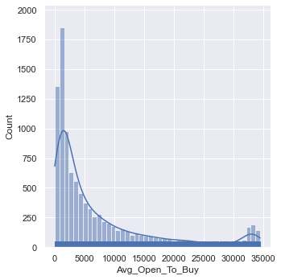

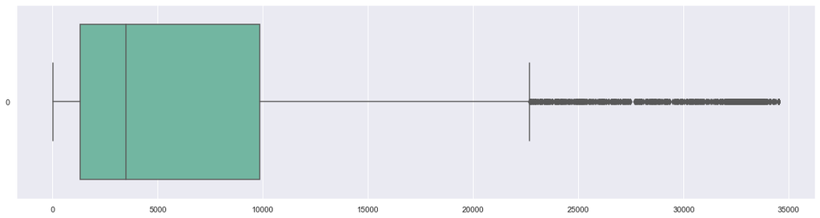

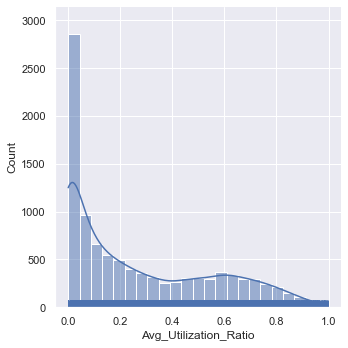

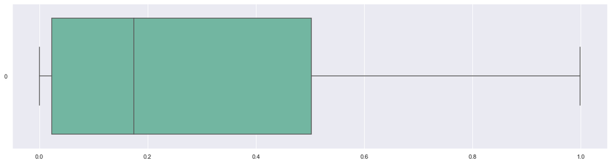

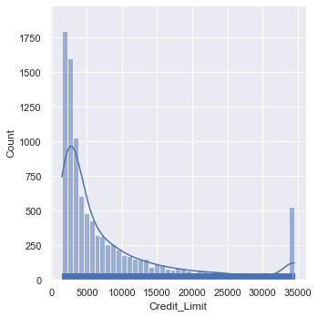

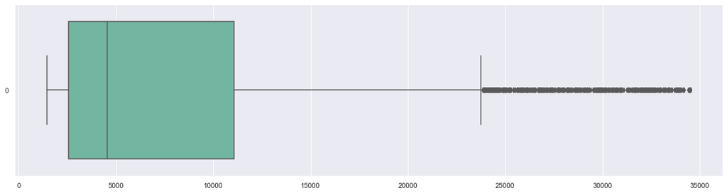

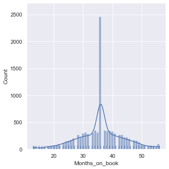

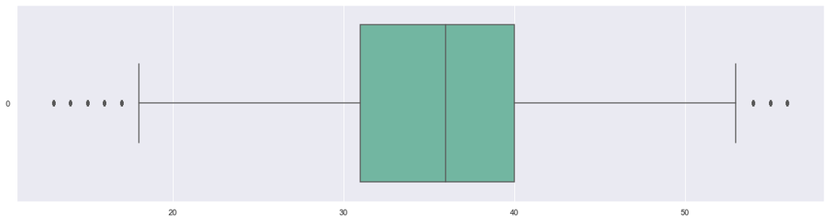

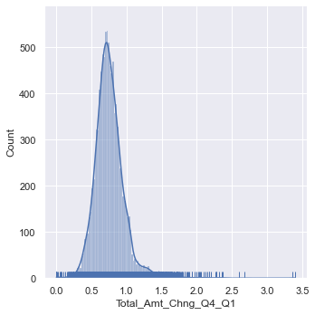

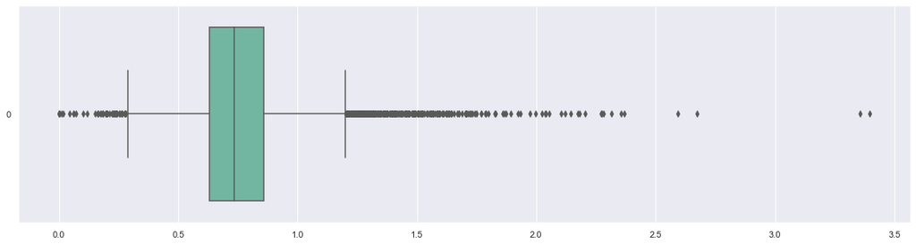

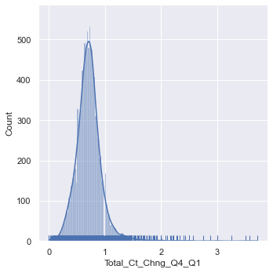

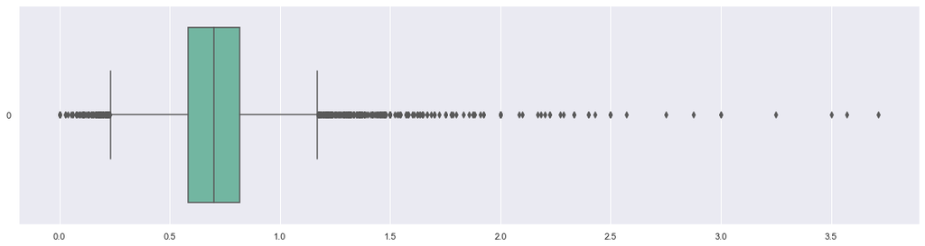

[6 more figures not shown]

```python
columns=['Avg_Open_To_Buy', 'Avg_Utilization_Ratio', 'Credit_Limit', 'Months_on_book', 'Total_Amt_Chng_Q4_Q1', 'Total_Ct_Chng_Q4_Q1', 'Total_Revolving_Bal', 'Total_Trans_Amt', 'Total_Trans_Ct']
for i in columns:
    myHB(mydata[i])
    print(seperator)
    plt.show()
```

### Client Profile Data observations

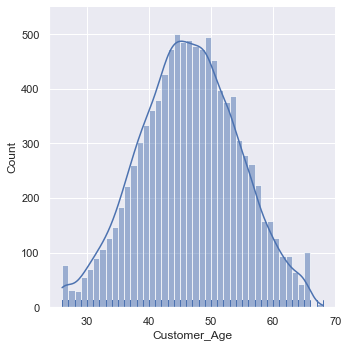

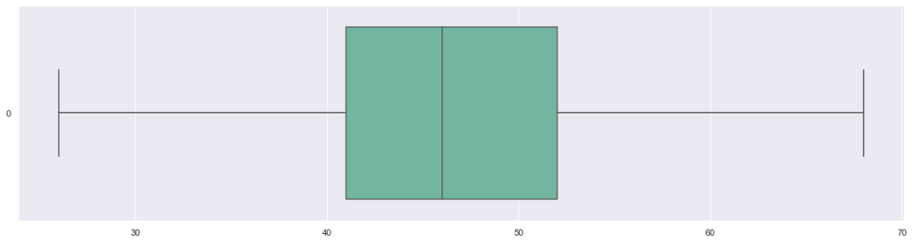

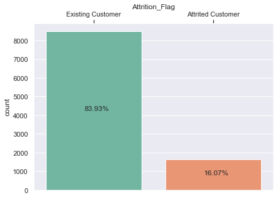

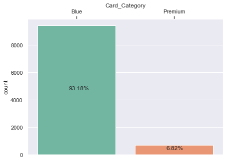

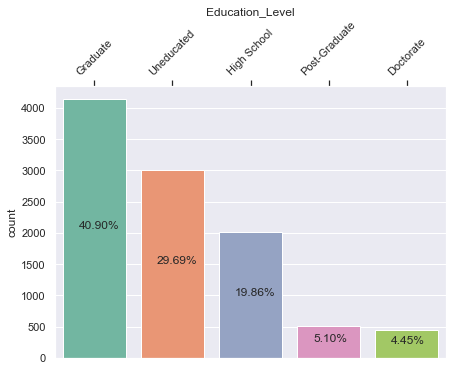

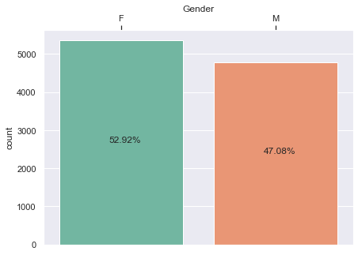

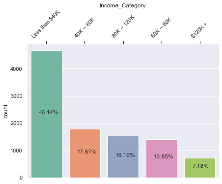

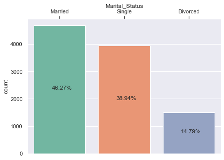

```python
myHB(mydata['Customer_Age'])

for i in mycatcols:
    myBar(mydata[i])
    print(seperator)
```

**Customer Age**

- Data will be normally distributed after outliers have been taken out.
- Customer Age is mostly normally distributed. Both tails seem to have a few spikes towards tails but are about even.
- Age box plot confirms outliers are not too significant.
- Too early to tell if Customer Age will be a factor.

**Gender**

**Dependent Count**

- Depedent_Count feature favors dependent counts of 2 & 3 most with a slight left skew.
- The extremes, 0 and 5, are the less frequent.
  - This may indicate most customers are married/cohabitating or divorced couples.

**Marital_Status**

- Has several *unknown* @ 7.4% so this was added to Divorced.
  - The Unknowns are likely to be Divorced or Single people.
  - To determine a good fit: A possible alternative approach for could have been based on ‘Dependent’ count.
- Married is the most dominant value for this feature with ‘Single’ following thereafter.

**Education_Level**

- Has several *unknown* @ 15% so this was added to Uneducated.
- Majority are Graduate is the highest category
- 'College' accounts for 10% which seems low so likely represents Graduate so has been combined.
- As expected Post-Graduate & Doctorate are the rarest, taking up only about 5% of each.
  - An alternative approach could have been to review Education Level with Income Category
  - Post-Graduate + Doctorate could have been combined but will leave as is

**Income_Category**

**Unknowns in categories:** Replaced Unknowns got "Uneducated" , "Divorced" & "Less than $40K" as those are social stigma may exist for these these may have been hesitant to report.

**Target Value is Attrition_Flag**

- There is a big imbalance, 16% customers have attrited.

**Card_Category**

- Most users have the blue category. This accounts for 90%+ of the data in this feature with a small amount trailing behind in silver, then a gold and platnum are almost none existant.
- May consider grouping Silver, Gold, & Platinum as Premium Cards

**Contacts_Count_12_mon** No. of Contacts in the last 12 months

**Months_Inactive_12_mon** No. of months inactive in the last 12 months

- Most customer, at least have 1-3 Relationship count, with most 3 & 2, respectively
- Very few had no countact or more than 3

**Total_Relationship_Count** Total Transaction Count (Last 12 months)

- Majority of cutomers had more than 3 Total Relationship counts

## Bivariate Analysis

### Correlation Heatmap

**Starting with this to minimize our feature count**

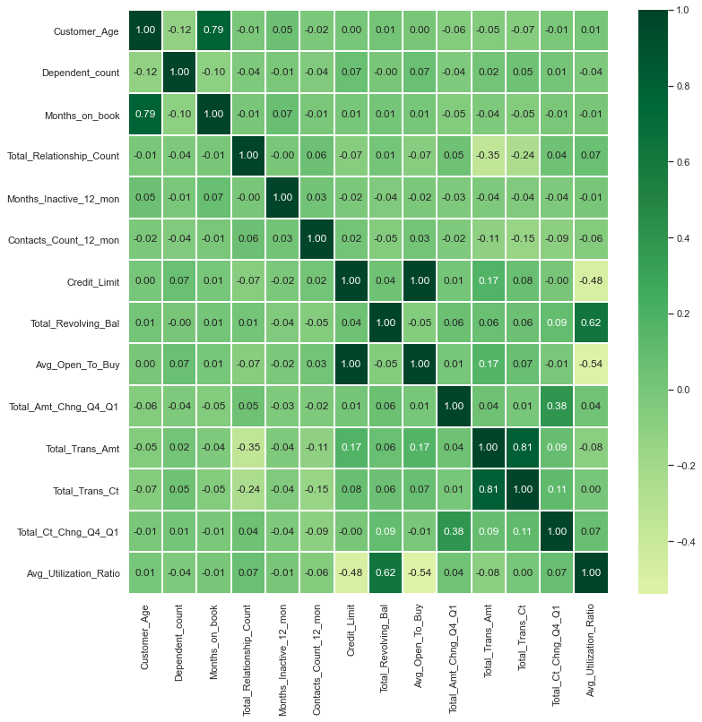

```
Wall time: 2.32 s
```

```python
%%time
sns.set(rc={'figure.figsize':(12,12)})
sns.heatmap(mydata.corr(), cmap="YlGn", cbar=True, linewidths=1, center=0, annot=True, fmt='0.2f')
plt.show()
```

Negative correlations of note

There were 3 high & 1 perfect positive correlation. Prefect correlation for perfect match 'Credit_Limit' & 'Avg_Open_To_Buy' @ 100%

- Can drop 'Avg_Open_To_Buy' as they are a perfect mirror of eachother Very High 'Total_Trans_Amt' & 'Total_Trans_Ct' @ 81%
- Can drop 'Total_Trans_Amt' as the frequency is likely more important Very High 'Customer_Age' & 'Months_on_book' @ 79%
- 'Customer_Age' can be dropped as Months on Book will have be signficance in 'loyalty'/'credit hopping'.

Will leave as is but good to note.

```python
mydata.drop(['Avg_Open_To_Buy','Total_Trans_Amt' ,'Customer_Age'], axis=1, inplace=True)
```

```python
### Function for barcharts
def mystack(x,flag=True):
    mypalette = 'Set2'
    sns.set(palette=mypalette)
    tab1 = pd.crosstab(x,mydata['Attrition_Flag'],margins=True)
    if flag==True:
        print(tab1)
        print('-'*120)
    tab = pd.crosstab(x, mydata['Attrition_Flag'], normalize='index')
    tab.plot(kind='bar',stacked=True,figsize=(5,3))
    plt.legend(loc='lower left', frameon=False)
    plt.legend(loc="upper left", bbox_to_anchor=(1,1))
    plt.show()
```

```
Wall time: 13.5 s
```

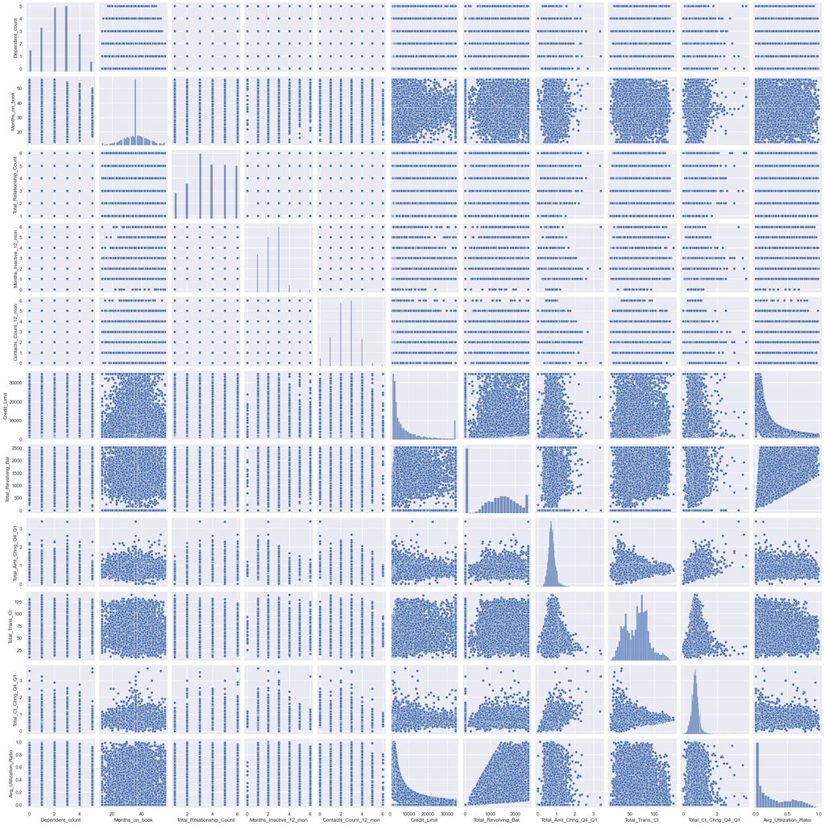

```python
%%time
sns.pairplot(mydata)
# sns.pairplot(mydata, hue='Attrition_Flag') #hue is off to cut back on run time
```

Plenty of overlapping no signficant linear correlations

- Only interesting relationship is Cedit Limit & Avg Utilization

```
Attrition_Flag     Attrited Customer  Existing Customer    All
Attrition_Flag
Attrited Customer               1627                  0   1627
Existing Customer                  0               8498   8498
All                             1627               8498  10125
------------------------------------------------------------------------------------------------------------------------
```

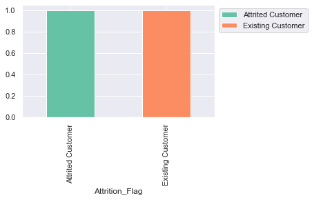

```
Attrition_Flag  Attrited Customer  Existing Customer    All
Card_Category
Blue                         1519               7915   9434
Premium                       108                583    691
All                          1627               8498  10125
------------------------------------------------------------------------------------------------------------------------
```

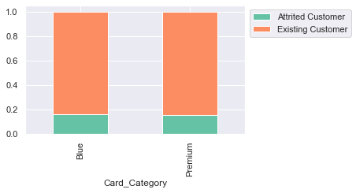

```
Attrition_Flag   Attrited Customer  Existing Customer    All
Education_Level
Doctorate                       95                356    451
Graduate                       641               3500   4141
High School                    306               1705   2011
Post-Graduate                   92                424    516
Uneducated                     493               2513   3006
All                           1627               8498  10125
------------------------------------------------------------------------------------------------------------------------
```

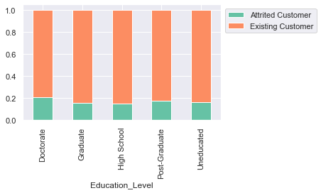

```
Attrition_Flag  Attrited Customer  Existing Customer    All
Gender
F                             930               4428   5358
M                             697               4070   4767
All                          1627               8498  10125
------------------------------------------------------------------------------------------------------------------------
```

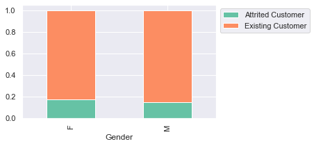

```
Attrition_Flag   Attrited Customer  Existing Customer    All
Income_Category
$120K +                        126                601    727
$40K - $60K                    271               1518   1789
$60K - $80K                    189               1213   1402
$80K - $120K                   242               1293   1535
Less than $40K                 799               3873   4672
All                           1627               8498  10125
------------------------------------------------------------------------------------------------------------------------
```

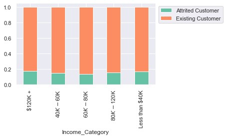

```
Attrition_Flag  Attrited Customer  Existing Customer    All
Marital_Status
Divorced                      250               1247   1497
Married                       709               3976   4685
Single                        668               3275   3943
All                          1627               8498  10125
------------------------------------------------------------------------------------------------------------------------
```

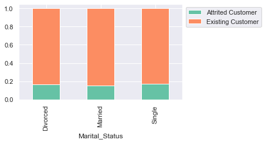

```python
col=mycatcols
for i in col:
    mystack(mydata[i])
```

Proportionally about the same Attrition rate for the following

- Education_Level (slight inclination to Dotorate education)
- Income_Category
  - Seems that 120k was the highest
- Credit
- Gender
- Marital_Status
- Dependent_count

## Data Preparation for our Model

```python
imputecols=["Education_Level" , "Income_Category" ,"Marital_Status"]
Dummy=["Card_Category" ,"Gender"]

onehot = ["Education_Level" , "Income_Category" ,"Marital_Status","Card_Category" ,"Gender"]
```

```python
replaceStruct = {'Education_Level': {'Uneducated':1, 'High School':2, 'Graduate':3, 'Post-Graduate':4, 'Doctorate':5}
,'Income_Category': {'Less than $51K':1,'$51K - $61K':2,'$81K - $131K':3, '$61K - $81K':4, '$131K +':5}
,'Marital_Status': {'Single':1, 'Married':1, 'Divorced':3}
,myTARGET: {'Attrited Customer':1, 'Existing Customer':0}
,'Card_Category': {'Premium':1, 'Blue':0}
,'Gender': {'M':1, 'F':0}
}
```

```python
mydata=mydata.replace(replaceStruct)
mydata=pd.get_dummies(mydata, columns=onehot, drop_first=True)
```

```python
mydata.info()
mydata.head(5)
```

```
<class 'pandas.core.frame.DataFrame'>
Int64Index: 10125 entries, 0 to 10126
Data columns (total 23 columns):
 #   Column                          Non-Null Count  Dtype
---  ------                          --------------  -----
 0   Attrition_Flag                  10125 non-null  int64
 1   Dependent_count                 10125 non-null  int64
 2   Months_on_book                  10125 non-null  int64
 3   Total_Relationship_Count        10125 non-null  int64
 4   Months_Inactive_12_mon          10125 non-null  int64
 5   Contacts_Count_12_mon           10125 non-null  int64
 6   Credit_Limit                    10125 non-null  float64
 7   Total_Revolving_Bal             10125 non-null  int64
 8   Total_Amt_Chng_Q4_Q1            10125 non-null  float64
 9   Total_Trans_Ct                  10125 non-null  int64
 10  Total_Ct_Chng_Q4_Q1             10125 non-null  float64
 11  Avg_Utilization_Ratio           10125 non-null  float64
 12  Education_Level_2               10125 non-null  uint8
 13  Education_Level_3               10125 non-null  uint8
 14  Education_Level_4               10125 non-null  uint8
 15  Education_Level_5               10125 non-null  uint8
 16  Income_Category_$40K - $60K     10125 non-null  uint8
 17  Income_Category_$60K - $80K     10125 non-null  uint8
 18  Income_Category_$80K - $120K    10125 non-null  uint8
 19  Income_Category_Less than $40K  10125 non-null  uint8
 20  Marital_Status_3                10125 non-null  uint8
 21  Card_Category_1                 10125 non-null  uint8
 22  Gender_1                        10125 non-null  uint8
dtypes: float64(4), int64(8), uint8(11)
memory usage: 1.4 MB
```

|  | Attrition_Flag | Dependent_count | Months_on_book | Total_Relationship_Count | Months_Inactive_12_mon | Contacts_Count_12_mon | Credit_Limit | Total_Revolving_Bal | Total_Amt_Chng_Q4_Q1 | Total_Trans_Ct | ... | Education_Level_3 | Education_Level_4 | Education_Level_5 | Income_Category_$40K - $60K | Income_Category_$60K - $80K | Income_Category_$80K - $120K | Income_Category_Less than $40K | Marital_Status_3 | Card_Category_1 | Gender_1 |
| --- | --- | --- | --- | --- | --- | --- | --- | --- | --- | --- | --- | --- | --- | --- | --- | --- | --- | --- | --- | --- | --- |
| 0 | 0 | 3 | 39 | 5 | 1 | 3 | 12691.0 | 777 | 1.335 | 42 | ... | 0 | 0 | 0 | 0 | 1 | 0 | 0 | 0 | 0 | 1 |
| 1 | 0 | 5 | 44 | 6 | 1 | 2 | 8256.0 | 864 | 1.541 | 33 | ... | 1 | 0 | 0 | 0 | 0 | 0 | 1 | 0 | 0 | 0 |
| 2 | 0 | 3 | 36 | 4 | 1 | 0 | 3418.0 | 0 | 2.594 | 20 | ... | 1 | 0 | 0 | 0 | 0 | 1 | 0 | 0 | 0 | 1 |
| 3 | 0 | 4 | 34 | 3 | 4 | 1 | 3313.0 | 2517 | 1.405 | 20 | ... | 0 | 0 | 0 | 0 | 0 | 0 | 1 | 1 | 0 | 0 |
| 4 | 0 | 3 | 21 | 5 | 1 | 0 | 4716.0 | 0 | 2.175 | 28 | ... | 0 | 0 | 0 | 0 | 1 | 0 | 0 | 0 | 0 | 1 |

5 rows × 23 columns

```python
mydata.isnull().sum()
```

```
Attrition_Flag                    0
Dependent_count                   0
Months_on_book                    0
Total_Relationship_Count          0
Months_Inactive_12_mon            0
Contacts_Count_12_mon             0
Credit_Limit                      0
Total_Revolving_Bal               0
Total_Amt_Chng_Q4_Q1              0
Total_Trans_Ct                    0
Total_Ct_Chng_Q4_Q1               0
Avg_Utilization_Ratio             0
Education_Level_2                 0
Education_Level_3                 0
Education_Level_4                 0
Education_Level_5                 0
Income_Category_$40K - $60K       0
Income_Category_$60K - $80K       0
Income_Category_$80K - $120K      0
Income_Category_Less than $40K    0
Marital_Status_3                  0
Card_Category_1                   0
Gender_1                          0
dtype: int64
```

```python
#Separating target variable and other variables
X=mydata.drop(columns=myTARGET,inplace=False)
Y=mydata[myTARGET]
```

```python
# #Splitting the data into train and test sets
X_train, X_test, y_train, y_test = train_test_split(
    X, Y, test_size=0.10, random_state=0, stratify=Y
)
print(X_train.shape, X_test.shape)
```

```
(9112, 22) (1013, 22)
```

# Building the model

```python
lr = LogisticRegression(random_state=1)
lr.fit(X_train,y_train)
```

```
LogisticRegression(random_state=1)
```

```python
def mscore(model, flag=True):
    score_list = []

    pred_train = model.predict(X_train)
    pred_test = model.predict(X_test)

    train_acc = model.score(X_train, y_train)
    test_acc = model.score(X_test, y_test)

    train_recall = metrics.recall_score(y_train, pred_train)
    test_recall = metrics.recall_score(y_test, pred_test)

    train_precision = metrics.precision_score(y_train, pred_train)
    test_precision = metrics.precision_score(y_test, pred_test)

    score_list.extend( ( train_acc, test_acc, train_recall, test_recall, train_precision, test_precision ) )

    # If the flag is set to True then only the following print statements will be dispayed. The default value is set to True.
    if flag == True:
        print("Accuracy on training set : ", model.score(X_train, y_train)*100)
        print("Accuracy on test set : ", model.score(X_test, y_test)*100)
        print("Recall on training set : ", metrics.recall_score(y_train, pred_train)*100)
        print("Recall on test set : ", metrics.recall_score(y_test, pred_test)*100)
        print("Precision on training set : ", metrics.precision_score(y_train, pred_train)*100)
        print("Precision on test set : ", metrics.precision_score(y_test, pred_test)*100)

    return score_list  # returning the list with train and test scores


def cm(model,y_actual , labels = [1, 0]):
    y_predict = model.predict(X_test)

    cm = confusion_matrix(y_test, y_predict)
    cmDF = pd.DataFrame(cm, index=[['Actual 0 - No','Actual 1 - Yes']], columns = [["Predict 0 - No", "Predict 1 - Yes"]])

    group_counts = ["{0:0.0f}".format(i) for i in cm.flatten()]
    group_percentages = ["{0:.2%}".format(i) for i in cm.flatten()/np.sum(cm)]
    labels = [f"{v1}\n{v2}" for v1, v2 in zip(group_counts,group_percentages)]
    labels = np.asarray(labels).reshape(2,2)

    plt.figure(figsize = (7,3))
    sns.heatmap(cmDF, annot = labels, fmt='', cmap='Blues', annot_kws={"size":15})

    # Individual Elements
    tn, fp, fn, tp = confusion_matrix(y_test, y_predict).ravel()
    print()
    print('True-Positive: ', tp)
    print('True-Negative: ', tn)
    print('False-Positive: ', fp)
    print('False-Negative: ', fn)

def compareM (comparemodels):
    acc_train = []
    acc_test = []
    recall_train = []
    recall_test = []
    precision_train = []
    precision_test = []

    for model in comparemodels:
        scores = mscore(model, False)
        acc_train.append(scores[0]*100)
        acc_test.append(scores[1]*100)
        recall_train.append(scores[2]*100)
        recall_test.append(scores[3]*100)
        precision_train.append(scores[4]*100)
        precision_test.append(scores[5]*100)
    return acc_test ,acc_train ,precision_test ,precision_train ,recall_test ,recall_train


def importantFeatures(model, show):
    importanceDF = pd.DataFrame(model.feature_importances_, columns = ["Importance"], index = X_train.columns).sort_values(by = 'Importance', ascending = False)
    if (show == True):
        #Boiler plate code
        feature_names = list(X.columns)
        importances = model.feature_importances_
        indices = np.argsort(importances)
        plt.figure(figsize=(10,12))
        plt.title('Feature Importances')
        plt.barh(range(len(indices)), importances[indices], color='blue', align='center')
        plt.yticks(range(len(indices)), [feature_names[i] for i in indices])
        plt.xlabel('Relative Importance')
        plt.show()

#         plt.figure(figsize=(5,10))
#         tree.plot_tree(dtree, feature_names=feature_names, filled=True, fontsize=9, node_ids=True, class_names=True)
#         plt.show()
    return importanceDF
```

## Logistic Regression

```
Accuracy on training set :  88.74012291483757
Accuracy on test set :  87.6604146100691
Recall on training set :  46.7896174863388
Recall on test set :  38.65030674846626
Precision on training set :  73.49785407725322
Precision on test set :  71.5909090909091

True-Positive:  63
True-Negative:  825
False-Positive:  25
False-Negative:  100
```

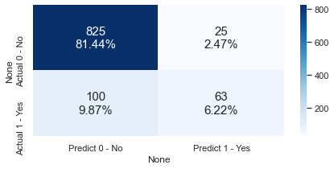

```python
LR=LogisticRegression(random_state=1).fit(X_train,y_train)
LRScore=mscore(LR)
cm(LR, y_train)
```